# Building the JetsNSharks model from scratch

This notebook builds the classic JetsNSharks model of human memory from scratch using basic R tools. The model shows how information about various individual people that might ordinarily be stored within a lookup table might be stored and retreived by a simple neural network that encodes (a) bidirectional positive connections between individuals and their properties and (b) bidirectional inhibitory connections among units that denote different mutually-incompatible values for a given kind of property, such as age or level of education.

First let’s look at the data table:

```r
dtab <- read.csv("JS_data_table.csv")
head(dtab)
```

|  | Name | Gang | Age | Education | Marriage | Job |
| --- | --- | --- | --- | --- | --- | --- |
| 1 | Art | Jets | 40s | JH | Sing | Pusher |
| 2 | Al | Jets | 30s | JH | Mar | Burglar |
| 3 | Sam | Jets | 20s | Coll | Sing | Bookie |
| 4 | Clyde | Jets | 40s | JH | Sing | Bookie |
| 5 | Mike | Jets | 30s | JH | Sing | Bookie |
| 6 | Jim | Jets | 20s | JH | Div | Burglar |

Each column encodes a particular kind of information; each row indicates properties of one individual person; and the various different entries within a column indicate all the possible values that can be adopted by that kind of information. So for *Gang*, every individual is either a Shark or a Jet. Note that the different possible values are mutually exclusive: one must be a Jet or a Shark but cannot be both.

In the network, each column corresponds to a “layer” or group of mutually inhibtory properties. Units within each layer correspond to the possible entries in the corresponding column. Individual people are kind of like the row number in the table: there is one unit for each individual in a central pool, and each such unit sends positive connections to / receives positive connections from the properties specified in the corresponding row of the table. So “individual 1” has the name Art, is a Jet, in his 40s, with a junior-high education, is single, and is a pusher; the corresponding unit will send positive connections to and receive positive connections from each of these units.

Units within a layer, because they correspond to mutually-exclusive values, compete for actiation: each such unit sends an inhibitory connection to all other units in the pool (and receives an inhibitory connection from other units in the pool). So if one unit get very active, it inhibits other values in the pool.

Let’s first collect names for all units in the network:

```r
unames <- c()
ncols <- dim(dtab)[2] #Number of columns in the data table

#Concatenate unique values from each column:
for(i in c(1:ncols)) unames <- c(unames, unique(dtab[,i]))
unames <- gsub(" ","",unames) #Remove any spaces
unames
```

```
 [1] "Art"     "Al"      "Sam"     "Clyde"   "Mike"    "Jim"     "Greg"
 [8] "John"    "Doug"    "Lance"   "George"  "Pete"    "Fred"    "Gene"
[15] "Ralph"   "Phil"    "Ike"     "Nick"    "Don"     "Ned"     "Karl"
[22] "Ken"     "Earl"    "Rick"    "Ol"      "Neal"    "Dave"    "Jets"
[29] "Sharks"  "40s"     "30s"     "20s"     "JH"      "Coll"    "HS"
[36] "Sing"    "Mar"     "Div"     "Pusher"  "Burglar" "Bookie"
```

This is good but we still need to have the units that stand for each individual. We could name those with row-numbers, but that might be hard to understand. Let’s instead use the *lower case* form of the person’s name to stand for the individual units, and append this to the front of the list of units:

```r
tmp <- tolower(dtab[,1])
tmp <- gsub(" ","", tmp)
unames <- c(tmp, unames)
rm(tmp)
unames
```

```
 [1] "art"     "al"      "sam"     "clyde"   "mike"    "jim"     "greg"
 [8] "john"    "doug"    "lance"   "george"  "pete"    "fred"    "gene"
[15] "ralph"   "phil"    "ike"     "nick"    "don"     "ned"     "karl"
[22] "ken"     "earl"    "rick"    "ol"      "neal"    "dave"    "Art"
[29] "Al"      "Sam"     "Clyde"   "Mike"    "Jim"     "Greg"    "John"
[36] "Doug"    "Lance"   "George"  "Pete"    "Fred"    "Gene"    "Ralph"
[43] "Phil"    "Ike"     "Nick"    "Don"     "Ned"     "Karl"    "Ken"
[50] "Earl"    "Rick"    "Ol"      "Neal"    "Dave"    "Jets"    "Sharks"
[57] "40s"     "30s"     "20s"     "JH"      "Coll"    "HS"      "Sing"
[64] "Mar"     "Div"     "Pusher"  "Burglar" "Bookie"
```

If we want to encode the current activation state across all units, we need a vector of the same length. And, we may as well name the elements of the vector according to the unit they represent:

```r
curract <- rep(0, times = length(unames))
names(curract) <- unames
curract["Ike"]
```

```
Ike
  0
```

We can directly set the activation of some set of units by just putting the corresponding values into the current activation vector:

[figure not shown]

```r
curract[c("Pusher", "20s")] <- 1
barplot(curract, las=2, cex.names = .5)
```

Given whatever input we specified, we want to now compute activations for all units in the network at the next step of time. To do this, the first thing we need is a matrix that stores the values of weights connecting pairs of units (and has a zero value where no such connection exists). I made this for you, load it now:

```r
w <- read.csv("JS_wts.csv", header = T, row.names = 1)
w <- as.matrix(w)
w[1:5,1:5]
```

```
          art al sam clyde mike
    art     0 -1  -1    -1   -1
    al     -1  0  -1    -1   -1
    sam    -1 -1   0    -1   -1
    clyde  -1 -1  -1     0   -1
    mike   -1 -1  -1    -1    0
```

```r
par(oma = c(2,2,2,2))
image(w[,68:1],xaxt = "n", yaxt = "n", col = c("blue","gray","red"))
mtext(side = 2, at = c(67:0/67), row.names(w), adj = 1, cex = 2, las = 2)
```

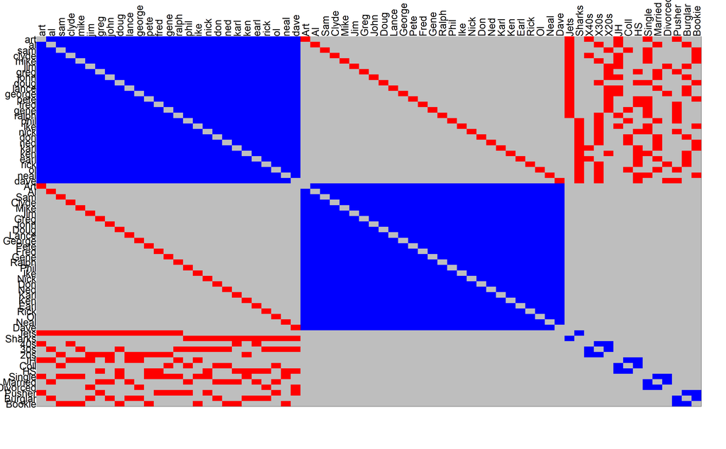

```r
mtext(side = 3, at = c(0:67)/67, colnames(w), cex = 2, adj = 0, las = 2)
```

To compute the activation of each unit at the next timestep, we first have to compute each unit’s net input. For a single unit, this is just the activation of each sending unit times the value of the weight going from the sending to the receiving unit. In the weight matrix, rows are sending units and columns are receiving units. So for a given unit, we can take the corresponding *column* of weights (weights going in to that unit) and for each, multiply the value of the weight by the current activation of the sending unit (stored in *curract*).

```r
#Make a vector to store current inputs to all units:
currinput <- rep(0, times = length(unames))
names(currinput) <- unames

#Now set some inputs to 1:
currinput[c("Jets", "Mar")] <- 1

#Compute the net input to the first unit:

sum(currinput * w[,1])
```

```
[1] 1
```

We could do this individually for each unit in the model with a *for* loop, but that is a bit slow and unweildy. Instead let’s use *matrix multiplication*:

```r
net <- currinput %*% w
net
```

```
     art al sam clyde mike jim greg john doug lance george pete fred gene
[1,]   1  2   1     1    1   1    2    2    1     2      1    1    1    1
     ralph phil ike nick don ned karl ken earl rick ol neal dave Art Al Sam
[1,]     1    1   0    0   1   1    1   0    1    0  1    0    0   0  0   0
     Clyde Mike Jim Greg John Doug Lance George Pete Fred Gene Ralph Phil
[1,]     0    0   0    0    0    0     0      0    0    0    0     0    0
     Ike Nick Don Ned Karl Ken Earl Rick Ol Neal Dave Jets Sharks X40s X30s
[1,]   0    0   0   0    0   0    0    0  0    0    0    0     -1    0    0
     X20s JH Coll HS Single Married Divorced Pusher Burglar Bookie
[1,]    0  0    0  0     -1       0       -1      0       0      0
```

```r
iacact(0, 1)
```

```
[1] 0.1
```

In our developing network, the current activations of the units are specified solely by the current input; from these we computed net inputs for all units in the model. So to compute the activations for all units on the next timestep, we just need to do:

```r
curract <- iacact(currinput, net)
curract
```

```
    art      al     sam   clyde    mike     jim    greg    john    doug   lance  george
    0.1     0.2     0.1     0.1     0.1     0.1     0.2     0.2     0.1     0.2     0.1
   pete    fred    gene   ralph    phil     ike    nick     don     ned    karl     ken
    0.1     0.1     0.1     0.1     0.1     0.0     0.0     0.1     0.1     0.1     0.0
   earl    rick      ol    neal    dave     Art      Al     Sam   Clyde    Mike     Jim
    0.1     0.0     0.1     0.0     0.0     0.0     0.0     0.0     0.0     0.0     0.0
   Greg    John    Doug   Lance  George    Pete    Fred    Gene   Ralph    Phil     Ike
    0.0     0.0     0.0     0.0     0.0     0.0     0.0     0.0     0.0     0.0     0.0
   Nick     Don     Ned    Karl     Ken    Earl    Rick      Ol    Neal    Dave    Jets
    0.0     0.0     0.0     0.0     0.0     0.0     0.0     0.0     0.0     0.0     0.9
 Sharks     40s     30s     20s      JH    Coll      HS    Sing     Mar     Div  Pusher
    0.0     0.0     0.0     0.0     0.0     0.0     0.0     0.0     0.9     0.0     0.0
Burglar  Bookie
    0.0     0.0
```

So this is what the current activations would be *if* some units didn’t also have direct input! For those units, we need to additionally make sure that they keep the same activation specified by the input:

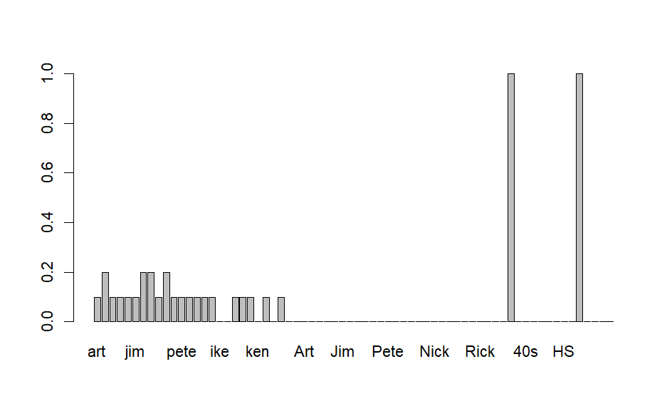

```r
#Make sure units with non-zero inputs adopt the input activation state:
curract[currinput != 0] <- currinput[currinput != 0]

#Visualize the activations:
barplot(curract)
```

So at one step of time, this is what activations look like! We can now go ahead and compute activation at the next time step, and the next and the next, etc—but first perhaps we should store the current activation in a data object so we can keep a record of the activation pattern at each time step:

```r
#Make an output matrix where rows are timepoints and columns are units:
outputs <- rbind(currinput, curract)

outputs[,1:5]
```

```
          art  al sam clyde mike
currinput 0.0 0.0 0.0   0.0  0.0
curract   0.1 0.2 0.1   0.1  0.1
```

To compute the activation on the next timestep, we just repeat the same computations from before: - Compute net input for next timestep - Compute new activations from current activations and current net input - Replace input values for units where this is specified - Add result as a new row in the output matrix

```r
net <- curract %*% w
curract <- iacact(curract, net)
curract[currinput != 0] <- currinput[currinput != 0]
outputs <- rbind(outputs, curract)
outputs[,1:5]
```

```
            art    al   sam clyde  mike
currinput 0.000 0.000 0.000 0.000 0.000
curract   0.100 0.200 0.100 0.100 0.100
curract   0.048 0.168 0.048 0.048 0.048
```

So now if we want to simulate propagation of the input activations over many timesteps, we can just repeatedly run these computations in a loop:

```r
#Let's update for 18 more timesteps:

for(i in c(1:18)){
  net <- curract %*% w
  curract <- iacact(curract, net)
  curract[currinput != 0] <- currinput[currinput != 0]
  outputs <- rbind(outputs, curract)
  }

outputs[,1:5]
```

```
                  art        al          sam       clyde        mike
currinput 0.000000000 0.0000000 0.0000000000 0.000000000 0.000000000
curract   0.100000000 0.2000000 0.1000000000 0.100000000 0.100000000
curract   0.048000000 0.1680000 0.0480000000 0.048000000 0.048000000
curract   0.038488000 0.2352320 0.0387360000 0.038240000 0.039480000
curract   0.028462361 0.2933077 0.0288483537 0.027744041 0.030692684
curract   0.019057091 0.3469054 0.0191465738 0.017544300 0.022455512
curract   0.010303142 0.3963394 0.0097221565 0.007756791 0.014691380
curract   0.002018465 0.4408533 0.0005063125 0.000000000 0.007187274
curract   0.000000000 0.4777633 0.0000000000 0.000000000 0.000000000
curract   0.000000000 0.5056200 0.0000000000 0.000000000 0.000000000
curract   0.000000000 0.5261170 0.0000000000 0.000000000 0.000000000
curract   0.000000000 0.5414929 0.0000000000 0.000000000 0.000000000
curract   0.000000000 0.5530197 0.0000000000 0.000000000 0.000000000
curract   0.000000000 0.5614672 0.0000000000 0.000000000 0.000000000
curract   0.000000000 0.5674459 0.0000000000 0.000000000 0.000000000
curract   0.000000000 0.5714854 0.0000000000 0.000000000 0.000000000
curract   0.000000000 0.5740236 0.0000000000 0.000000000 0.000000000
curract   0.000000000 0.5754244 0.0000000000 0.000000000 0.000000000
curract   0.000000000 0.5759821 0.0000000000 0.000000000 0.000000000
curract   0.000000000 0.5759324 0.0000000000 0.000000000 0.000000000
curract   0.000000000 0.5754640 0.0000000000 0.000000000 0.000000000
```

We can look at the final pattern of activation across all units:

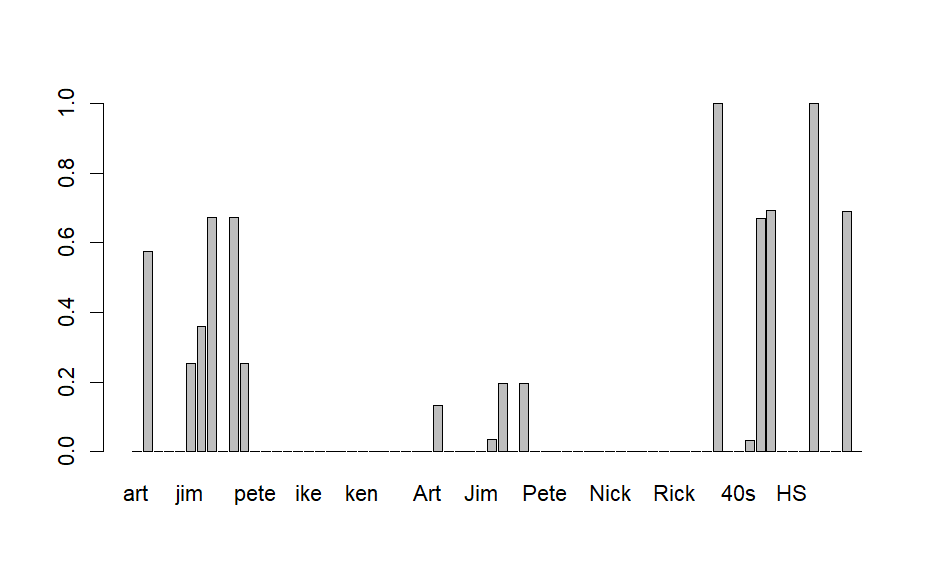

```r
barplot(outputs[21,])
```

…we can look at how activations change over time for each unit:

```r
plot(0,0,type ="n", xlab = "Time", ylab ="Activation", ylim = c(0,1), xlim = c(0,20))

for(i in c(1:68)) lines(0:20, outputs[,i])
```

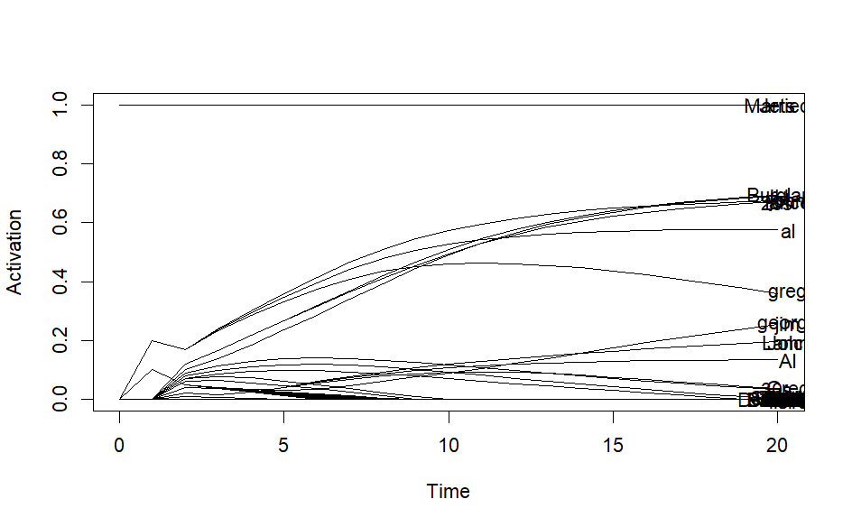

```r
text(rep(20, times = 68), outputs[21,], labels = row.names(w))
```